# Rossmann-Analyse

# 8. Clusteranalyse

## 8.1 Hierarchical Clustering als distanzbasiertes Verfahren

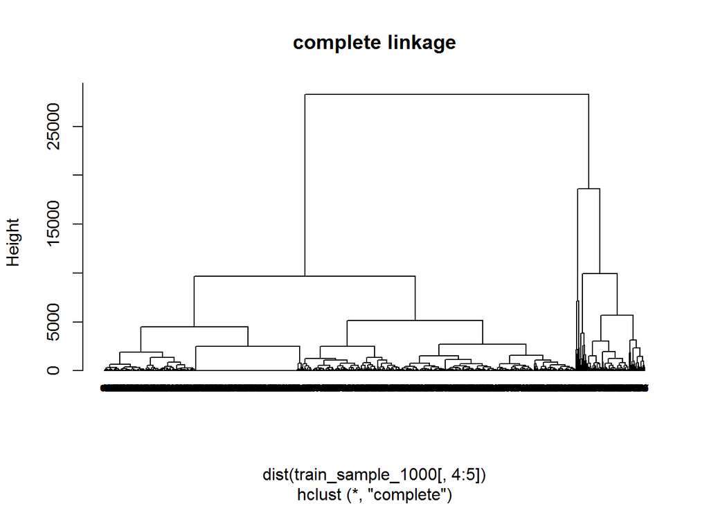

```r
# Clustering nach Sortimentstufe bezogen auf Sales und Kundenanzahl
# complete
hc_complete <- hclust(dist(train_sample_1000[,4:5]), method="complete")
plot(hc_complete, hang = -1, main = "complete linkage", labels=train_sample_1000$Assortment, cex=.9)
```

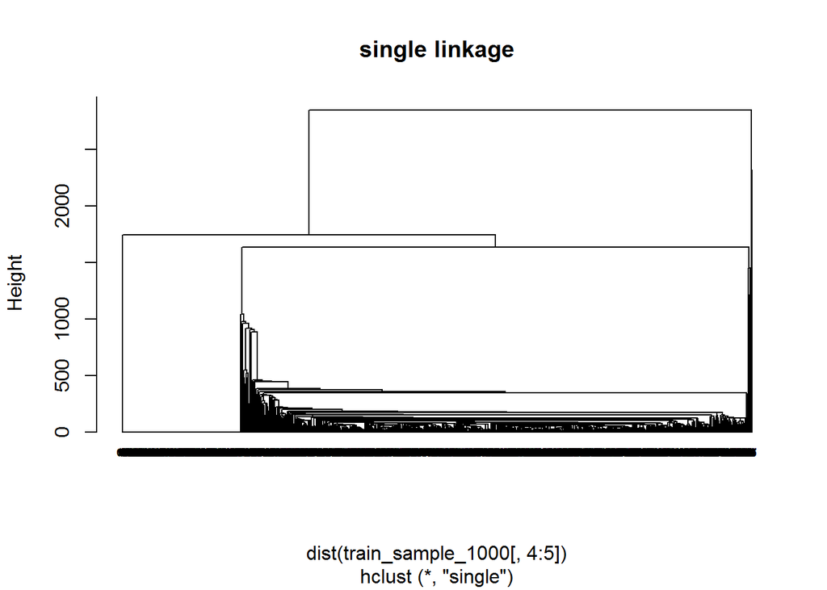

```r
# single
hc_single <- hclust(dist(train_sample_1000[,4:5]), method="single")
plot(hc_single, hang = -1, main = "single linkage", labels=train_sample_1000$Assortment, cex=.9)
# centroid
hc_cen <- hclust(dist(train_sample_1000[,4:5]), method="single")
plot(hc_single, hang = -1, main = "single linkage", labels=train_sample_1000$Assortment, cex=.9)
```

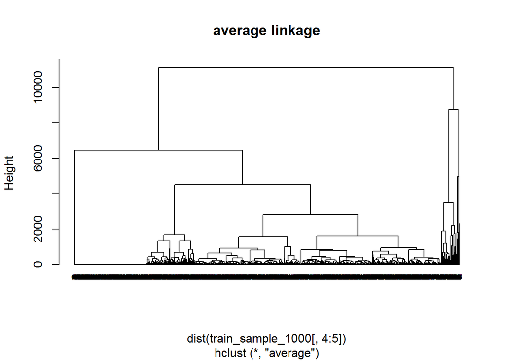

```r
# average
hc_average <- hclust(dist(train_sample_1000[,4:5]), method="average")
dend_hc_average <- as.dendrogram(hc_average)
plot(hc_average, hang = -1, main = "average linkage", labels=train_sample_1000$Assortment, cex=.9)
```

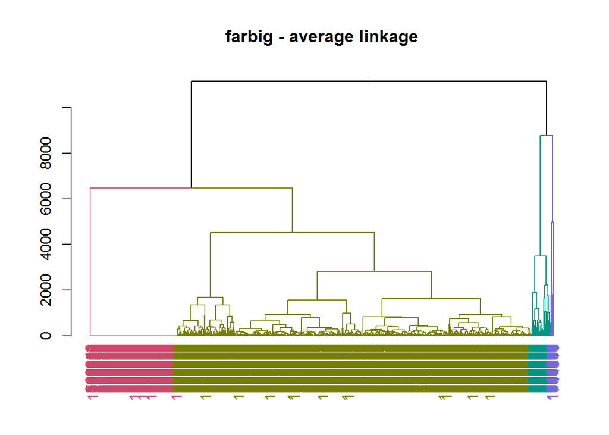

```r
dend <- dend_hc_average
dend <- color_branches(dend, k = 4)
dend <- color_labels(dend, k = 4)
plot(dend, main = "farbig - average linkage")
```

**Ergebnis:** Es wurde versucht die Varianz zwischen Clustern zu maximieren (Between-Clustervarianz). Hierbei kamen verschiedene Verfahren (complete, single und average linkage) für die Distanzberechnung zum Einsatz. Der letzte Plot visualisiert farblich 4 Cluster, die ähnliche Objekte gruppieren.

## 8.2 K-means zur Varianzminimierung innerhalb der Cluster

```r
# run kmeans mit 4 zufällig gewählten Zentren
kc <- kmeans(train_sample_1000[,4:5], 4, nstart = 1)
table(train_sample_1000$Assortment, kc$cluster)
```

```
##
##       1   2   3   4
##   a 136 103 234  26
##   b   3   0   5   2
##   c 167  95 206  23
```

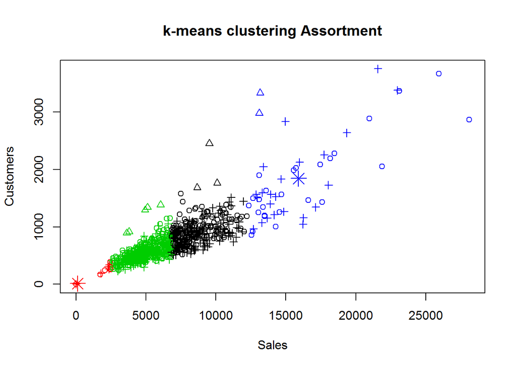

```r
# Farbig nach gefundenen clustern
plot(train_sample_1000[c("Sales", "Customers")], pch = unclass(train_sample_1000$Assortment),
     col = kc$cluster,  main = "k-means clustering Assortment")
points(kc$centers[,c("Sales", "Customers")], col = 1:4, pch = 8, cex=2)
```

**Ergebnis:** Es wurde versucht Assortment zu clustern bezogen auf Sales und Customer. Unter der Annahme, dass ein Store anders kategorisiert wurde, als in der Realität, ist ein Sortimentwechsel evtl. lohnenswert.

## 8.3 Vergleich der Ergebnisse aus hierachical und k-means clustering

```r
hc_average_cut <- cutree(hc_average,4)
table(hc_average_cut, kc$cluster)
```

```
##
## hc_average_cut   1   2   3   4
##              1 306  10 445   4
##              2   0 188   0   0
##              3   0   0   0  40
##              4   0   0   0   7
```

**Ergebnis:** In der Tabelle werden die von den beiden Verfahren vorhergesagten Cluster (von Oben –> siehe 8.1, 8.2) gegenübergestellt. Hier sehen wir einerseits die Übereinstimmungen (445, 306, 188, 40) und die Misclassifications hier 3 an der Zahl -> (4,7,10), bei denen die Verfahren unterschiedliche Ergebnisse lieferten.

# 9. Trees

## 9.1 Regression Trees

```r
#set.seed(1)
train = sample(1:nrow(joinedData), nrow(joinedData) * 0.8)
reg_tree.joinedData=tree(Sales~.-Date ,joinedData,subset=train)
summary(reg_tree.joinedData)
```

```
##
## Regression tree:
## tree(formula = Sales ~ . - Date, data = joinedData, subset = train)
## Variables actually used in tree construction:
## [1] "Customers" "StoreType" "Promo"
## Number of terminal nodes:  8
## Residual mean deviance:  2110000 = 5.29e+11 / 251000
## Distribution of residuals:
##    Min. 1st Qu.  Median    Mean 3rd Qu.    Max.
##   -7080    -839     -27       0     646   27900
```

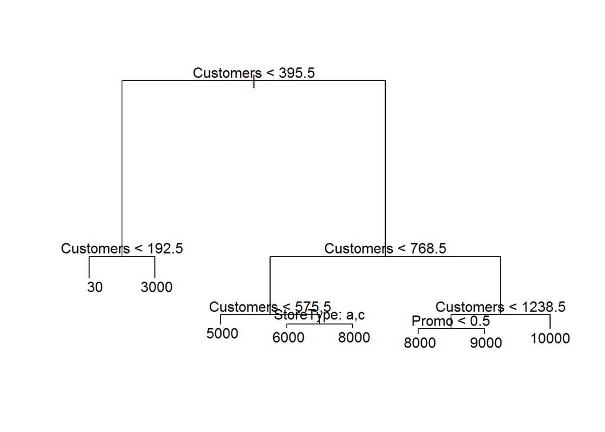

```r
plot(reg_tree.joinedData)
text(reg_tree.joinedData,pretty=0)
```

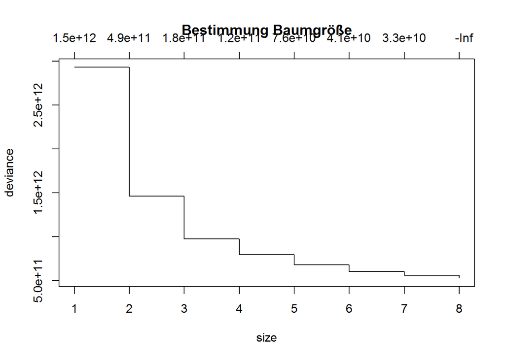

```r
cv.joinedData=cv.tree(reg_tree.joinedData)
plot(cv.joinedData, main = "Bestimmung Baumgröße")
```

**Ergebnis:** Nach Training des Regressionsbaumes spielt Customeranzahl die größte Rolle. Die Auswahl der Einflussvariablen bestätigt die Nutzung dieser Variblen bei der linearen Regression. Aus dem Plot “Bestimmung Baumgröße” lässt sich ablesen, dass ungefähr bei 4 der Fehler nicht wesentlich besser wird.

## 9.2 Decision Trees

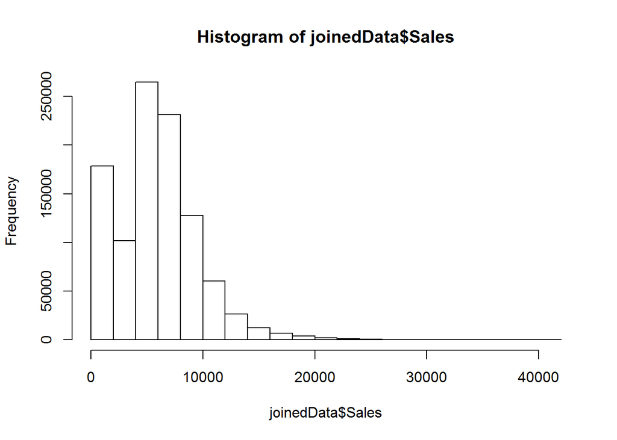

```r
joinedData <- read.csv("traindata_joined_with_store_COMMA.csv")

# Häufigkeit der Umsätze anschauen
hist(joinedData$Sales)
```

```r
# Sales<=5000 EUR werden als KLEIN eingestufft (HighSales="No"), Sales>5000EUR als GROSS (HighSales="Yes")
HighSales=ifelse(joinedData$Sales<=5000,"No","Yes")
joinedData=data.frame(joinedData,HighSales)

# Baum trainieren
## - Date, sonst Error: Error in tree(HighSales ~ . - Sales, joinedData) : factor predictors must have at most 32 levels
tree.joinedData=tree(HighSales~.-Sales-Date,joinedData)
summary(tree.joinedData)
```

```
##
## Classification tree:
## tree(formula = HighSales ~ . - Sales - Date, data = joinedData)
## Variables actually used in tree construction:
## [1] "Customers"           "StoreType"           "Promo"
## [4] "CompetitionDistance"
## Number of terminal nodes:  9
## Residual mean deviance:  0.513 = 161000 / 314000
## Misclassification error rate: 0.117 = 36822 / 313914
```

**Bemerkung:** Ziel ist Einstufung von Filialen in Groß und Klein in Abhängigkeit zu Sales.

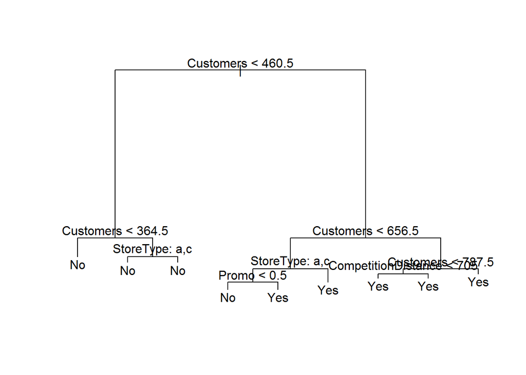

```r
#Baum ausgeben
plot(tree.joinedData); text(tree.joinedData,pretty=0)
```

```r
tree.joinedData
```

```
## node), split, n, deviance, yval, (yprob)
##       * denotes terminal node
##
##  1) root 313914 4e+05 Yes ( 0 1 )
##    2) Customers < 460.5 104909 6e+04 No ( 1 0 )
##      4) Customers < 364.5 69534 4e+03 No ( 1 0 ) *
##      5) Customers > 364.5 35375 4e+04 No ( 1 0 )
##       10) StoreType: a,c 18319 1e+04 No ( 1 0 ) *
##       11) StoreType: d 17056 2e+04 No ( 1 0 ) *
##    3) Customers > 460.5 209005 2e+05 Yes ( 0 1 )
##      6) Customers < 656.5 93764 1e+05 Yes ( 0 1 )
##       12) StoreType: a,c 57992 8e+04 Yes ( 0 1 )
##         24) Promo < 0.5 34542 5e+04 No ( 1 0 ) *
##         25) Promo > 0.5 23450 3e+04 Yes ( 0 1 ) *
##       13) StoreType: d 35772 2e+04 Yes ( 0 1 ) *
##      7) Customers > 656.5 115241 4e+04 Yes ( 0 1 )
##       14) Customers < 787.5 45499 3e+04 Yes ( 0 1 )
##         28) CompetitionDistance < 705 13105 1e+04 Yes ( 0 1 ) *
##         29) CompetitionDistance > 705 32394 7e+03 Yes ( 0 1 ) *
##       15) Customers > 787.5 69742 5e+03 Yes ( 0 1 ) *
```

**Ergebnis:** Nach dem Training des Klassifikationsbaumes, ist ersichtlich, dass die erste Aufteilung bezogen auf Customeranzahl stattfinden muss, gefolgt von Storetype und Promo… Die Distanz zur nächsten Aufzweigung spiegelt den SSE Wert wider.